# AB Testing and Securities Analysis

Bradley Wallace

10/06/2020

#### Question 1 Part A and B

*1.A) Now compute the difference estimator for treatment 1 and treatment 2 datasets that were created, in comparison with the control group?*

Beta, trt1 = -0.3710, not significant,

*1.B) From the PlantGrowth dataset what is the average crop weight of the control group, treatment 1 group, and treatment 2 group, comment on which group has the highest average?*

Mean Control = 5.032, Mean Treatment 1 = 4.661, Mean Treatment 2 = 5.526,

Beta, trt1 = Mean Treatment 1 - Mean Control = -0.371,

Beta, trt2 = Mean Treatment 2 - Mean Control =0.494,

Same as Part A i.e. using averages results in the same difference estimators as using linear regression.

```r
library(datasets) # load the library containing the dataset
data1 <- PlantGrowth # load the dataset
summary(data1) # summary of dataset
```

```
##      weight       group
##  Min.   :3.590   ctrl:10
##  1st Qu.:4.550   trt1:10
##  Median :5.155   trt2:10
##  Mean   :5.073
##  3rd Qu.:5.530
##  Max.   :6.310
```

```r
head(data1) # first few rows of dataset
```

```
##   weight group
## 1   4.17  ctrl
## 2   5.58  ctrl
## 3   5.18  ctrl
## 4   6.11  ctrl
## 5   4.50  ctrl
## 6   4.61  ctrl
```

```r
### Data Preparation ###
# split datasets as required - control + treatment group 1 and control + treatment group 2
data_group_1 <- data1[c(which(data1$group=="ctrl"),which(data1$group=="trt1")),]
data_group_2 <- data1[c(which(data1$group=="ctrl"),which(data1$group=="trt2")),]

data_group_1_alt <- dplyr::filter(data1, group=="ctrl"|group=="trt1")
data_group_2_alt <- dplyr::filter(data1, group=="ctrl"|group=="trt2")

### Part A ###
# estimate difference estimator using linea regression (lm)
model1 <- lm(weight~group,data=data_group_1)
model2 <- lm(weight~group,data=data_group_2)

# print summary of linear regression models to see difference estimator
summary(model1)
```

```
##
## Call:
## lm(formula = weight ~ group, data = data_group_1)
##
## Residuals:
##     Min      1Q  Median      3Q     Max
## -1.0710 -0.4938  0.0685  0.2462  1.3690
##
## Coefficients:
##             Estimate Std. Error t value Pr(>|t|)
## (Intercept)   5.0320     0.2202  22.850 9.55e-15 ***
## grouptrt1    -0.3710     0.3114  -1.191    0.249
## ---
## Signif. codes:  0 '***' 0.001 '**' 0.01 '*' 0.05 '.' 0.1 ' ' 1
##
## Residual standard error: 0.6964 on 18 degrees of freedom
## Multiple R-squared:  0.07308,    Adjusted R-squared:  0.02158
## F-statistic: 1.419 on 1 and 18 DF,  p-value: 0.249
```

```r
summary(model2)
```

```
##
## Call:
## lm(formula = weight ~ group, data = data_group_2)
##
## Residuals:
##    Min     1Q Median     3Q    Max
## -0.862 -0.410 -0.006  0.280  1.078
##
## Coefficients:
##             Estimate Std. Error t value Pr(>|t|)
## (Intercept)   5.0320     0.1637  30.742   <2e-16 ***
## grouptrt2     0.4940     0.2315   2.134   0.0469 *
## ---
## Signif. codes:  0 '***' 0.001 '**' 0.01 '*' 0.05 '.' 0.1 ' ' 1
##
## Residual standard error: 0.5176 on 18 degrees of freedom
## Multiple R-squared:  0.2019, Adjusted R-squared:  0.1576
## F-statistic: 4.554 on 1 and 18 DF,  p-value: 0.04685
```

```r
### Part B ###
# calculate average crop weight of control, treatment group 1 and treatment group 2
mean_ctrl = mean(data1[which(data1$group=="ctrl"),1])
mean_trt1 = mean(data1[which(data1$group=="trt1"),1])
mean_trt2 = mean(data1[which(data1$group=="trt2"),1])

# print averages (i.e. means) results
print(mean_ctrl)
```

```
## [1] 5.032
```

```r
print(mean_trt1)
```

```
## [1] 4.661
```

```r
print(mean_trt2)
```

```
## [1] 5.526
```

```r
### Part A Check, using Part B ###
# calculate difference estimators using averages (alternative method) to check answer to Part A
print(mean_trt1 - mean_ctrl)
```

```
## [1] -0.371
```

```r
print(mean_trt2 - mean_ctrl)
```

```
## [1] 0.494
```

#### Question 1 Part C, D and E

*1.C) In the above problem, Classify the workers into four groups and assign the corresponding group with the group title (A, B, C, and D).*

Refer Code below

*1.D) To estimate the difference in the difference we need four averages for the above-categorized groups i.e., control group before change, control group after change, treatment group before change, and treatment group after the change. Compute the following:*

*i) Calculate the mean of the ‘fte’ variable for each of the four groups in R and print them*

Group A Mean = 23.38 # Control before, t=0,

Group B Mean = 20.43058 # Treated before, t=0,

Group C Mean = 21.09667 # Control after, t=1,

Group D Mean = 20.89725 # Treated after, t=1,

*ii) Using these averages estimate the value of the difference in difference*

*1.E) Estimate the DID (Difference in Difference) using a regression model.*

DID, using linear regression = b3 = d_nj coefficient = 2.750

```r
data2 <- read.csv("F:/Documents/Min_Wage.csv")

### Part C ###

group_a <- data2[which(data2$d==0 & data2$State=="Philadelphia"),] # Control before, t=0
group_b <- data2[which(data2$d==0 & data2$State=="New Jersey"),] # Treated before, t=0
group_c <- data2[which(data2$d==1 & data2$State=="Philadelphia"),] # Control after, t=1
group_d <- data2[which(data2$d==1 & data2$State=="New Jersey"),] # Treated after, t=1

group_a_alt <- dplyr::filter(data2, d==0 & State=="Philadelphia")
group_b_alt <- dplyr::filter(data2, d==0 & State=="New Jersey")
group_a_alt <- dplyr::filter(data2, d==1 & State=="Philadelphia")
group_d_alt <- dplyr::filter(data2, d==1 & State=="New Jersey")

### Part D ###
## Section i) ##

group_a_mean <- mean(group_a$fte) # Control before, t=0
group_b_mean <- mean(group_b$fte) # Treated before, t=0
group_c_mean <- mean(group_c$fte) # Control after, t=1
group_d_mean <- mean(group_d$fte) # Treated after, t=1

print(group_a_mean)
```

```
## [1] 23.38
```

```r
print(group_b_mean)
```

```
## [1] 20.43058
```

```r
print(group_c_mean)
```

```
## [1] 21.09667
```

```r
print(group_d_mean)
```

```
## [1] 20.89725
```

```r
## Section ii) ##
DID = (group_d_mean - group_b_mean) - (group_c_mean - group_a_mean) # calculte Diff in Diff using averages

print(DID)
```

```
## [1] 2.75
```

```r
### Part E ###

data2$nj = ifelse(data2$State=="New Jersey", 1, 0) # Create missing dummy variable for New_Jersey as "nj"
model3 <- lm(fte ~ d + nj + d_nj,data=data2) # calculte Diff in Diff using linear regression with all necessary dummy variables
summary(model3) # print linear regression summary
```

```
##
## Call:
## lm(formula = fte ~ d + nj + d_nj, data = data2)
##
## Residuals:
##     Min      1Q  Median      3Q     Max
## -21.097  -6.472  -0.931   4.603  64.569
##
## Coefficients:
##             Estimate Std. Error t value Pr(>|t|)
## (Intercept)   23.380      1.098  21.288   <2e-16 ***
## d             -2.283      1.553  -1.470   0.1419
## nj            -2.949      1.224  -2.409   0.0162 *
## d_nj           2.750      1.731   1.588   0.1126
## ---
## Signif. codes:  0 '***' 0.001 '**' 0.01 '*' 0.05 '.' 0.1 ' ' 1
##
## Residual standard error: 9.511 on 764 degrees of freedom
## Multiple R-squared:  0.007587,   Adjusted R-squared:  0.00369
## F-statistic: 1.947 on 3 and 764 DF,  p-value: 0.1206
```

```r
# DID = b3 = d_nj coefficient = 2.750
```

#### Question 2 - Berkshire Hathaway Analysis

*For Parts A, B, C, D, E, F, G, H, and I: using the dataset Berkshire.csvPreview the document with the following variables:*

Column (1): Date, Calendar Date Column (2): BRKret, Berkshire Hathaway’s monthly return Column (3): MKT, the return on the aggregate stock market Column (4): RF, the risk free rate of return

*Round all answers to the nearest hundredth.*

*2.A) Find the standard deviation of Berkshire Hathaway over the sample period.*

Output: StdDev 0.06752971,

6.75% per month

Output: Annualized Standard Deviation 0.2339298,

23.39% per year

*2.B) Find Berkshire Hathaway’s average return over the sample period?*

Output: Mean 0.0189872,

1.90% per month

*2.C) By what percentage per month on average has Berkshire Hathaway outperformed the market?*

Output: 0.0088286

0.88% per month

*2.D) $10,000 invested in Berkshire Hathaway at the start of the sample period would have grown to ____ by the end of the sample period.*

Output: $41,439,896

$10,000 multiplied by 4143.99, the cumulative return of Berkshire Hathaway from 1976 to 2018,

1 dollar invested in Berkshire Hathaway in 1976 becomes an astonding 4143.99 dollars in 2018.

*2.E) Plot the cumulative return of Berkshire and Market across all years and include a legend. Describe your observation. Combine the Plots.*

Refer Plots and Code

The cumulative return over the entire timeline is staggeringly higher for Berkshire Hathaway. 96.22 - 1 dollar invested in a market index fund in 1976 (i.e. follows the overall market return) becomes 96.22 dollars in 2018. 4143.99 - 1 dollar invested in Berkshire Hathaway in 1976 becomes an astonding 4143.99 dollars in 2018.

The 1988-89 recession is hardly visible in Berkshire Hathaway’s cumulative returns due to the magnitude of overall growth.

Relative performance shows Berkshire Hathaway’s cumulative returns ranged from 40-50 times that of the aggregate stock market (excluding peaks) from 2002 to 2018. Berkshire Hathaway’s cumulative returns grew to these levels from a 1:1 in 1976 to 2002 which implies to me that the outperformance of Berkshire Hathaway compared to the market had a staggering compounding effect.

*2.F) What is Berkshire Hathaway’s monthly Sharpe ratio?*

Sharpe Ratio of Berkshire Hathaway = 0.23

BrkRet  
StdDev Sharpe (Rf=0.4%, p=95%): 0.2262115 VaR Sharpe (Rf=0.4%, p=95%): 0.2060944 ES Sharpe (Rf=0.4%, p=95%): 0.1728184

*2.G) What is the Sharpe Ratio for the market index? Comparing this value to Berkshire Hathaway’s Sharpe ratio. Which one is higher and what does that mean?*

Sharpe Ratio of Market = 0.15

Berkshire Hathaway’s Sharpe ratio is higher (0.23 vs. 0.15). A higher Sharpe ratio means that Berkshire Hathaway has a better risk-adjusted performance than the overall (aggregate) stock market e.g. an index market fund such as VTI or the S&P500.

MKT StdDev Sharpe (Rf=0.4%, p=95%): 0.14794528 VaR Sharpe (Rf=0.4%, p=95%): 0.09486128 ES Sharpe (Rf=0.4%, p=95%): 0.05677763

*2.H) What is Berkshire Hathaway’s estimated beta?*

Output: 0.689755 *** significance,

beta = MKT_Ex coefficient = 0.69

*2.I) On a monthly basis, what is Jensen’s alpha for Berkshire Hathaway?*

Output: 0.010829 *** significance,

Jensen’s alpha = intercept value = 1.08% per month or 108 basis points per month

*Extra Commentary* Adjusted R^2 = 0.20, so the linear regression model only explains 20% of the variation between Berkshire Hathaway’s Excess Return and the aggregate market Excess Return. Also, the F-statistic is significant, so there is a relationship between these two excess returns.

```r
# load required dependencies
library(PerformanceAnalytics)
library(xts)
library(lubridate)
```

```r
library(ggplot2)
# load dataset and prepare dataset with excess returns for Berkshire Hathaway and the overall aggregate stock market
data3 <- read.csv("F:/Documents/Berkshire.csv")
data3$BrkRet_Ex <- data3$BrkRet - data3$RF
data3$MKT_Ex <- data3$MKT - data3$RF

data3$Date <- mdy(data3$Date) # convert dataset dates to "month-day-year" format
fund <- data3[order(data3$Date),] # create new dataset called "fund" with ordered date-time

All.dat <- xts(fund[,-1],order.by=fund[,1],) # convert dataset to time-series

### Part A ###
StdDev(All.dat$BrkRet) # use standard deviation function
```

```
##              [,1]
## StdDev 0.06752971
```

```r
StdDev.annualized(All.dat$BrkRet) # use annualized standard deviation function
```

```
##                                  BrkRet
## Annualized Standard Deviation 0.2339298
```

```r
### Part B ###
mean(All.dat$BrkRet) # calculate average
```

```
## [1] 0.0189872
```

```r
### Part C ###
mean(All.dat$BrkRet) - mean(All.dat$MKT) # calculate average outperformance by using part B and subtracting average market return
```

```
## [1] 0.0088286
```

```r
### Part D ###
Q2D <- Return.cumulative(All.dat$BrkRet,geometric=TRUE) # calculate cumulative return of Berkshire Hathaway over full time period
Q2D # check cumulative return
```

```
##                    BrkRet
## Cumulative Return 4143.99
```

```r
Q2D*10000 #  calculate cumulative return of $10000 initially invested
```

```
##                     BrkRet
## Cumulative Return 41439896
```

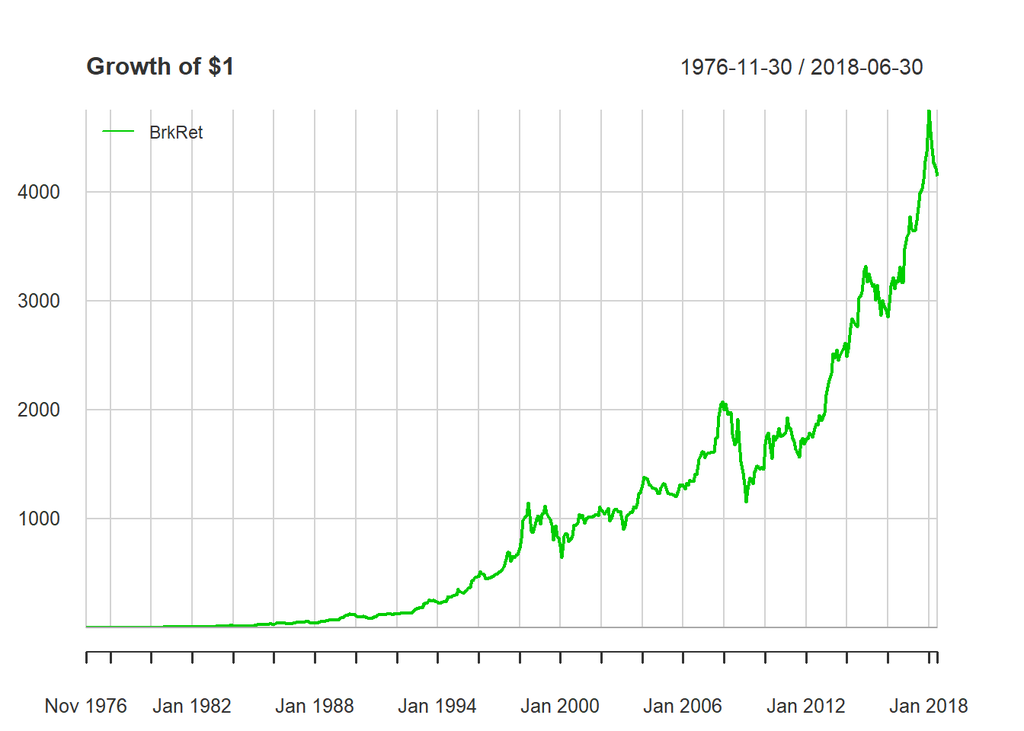

```r
### Part E ###
plot1 <- chart.CumReturns(All.dat$BrkRet,
                 wealth.index = FALSE,
                 geometric = TRUE,
                 legend.loc = TRUE,
                 colorset = 3,
                 main="Growth of $1")
plot2 <- chart.CumReturns(All.dat$MKT,
                 wealth.index = FALSE,
                 Geometric = TRUE,
                 legend.loc = TRUE,
                 colorset = 4,
                 main="Growth of $1")
plot1
```

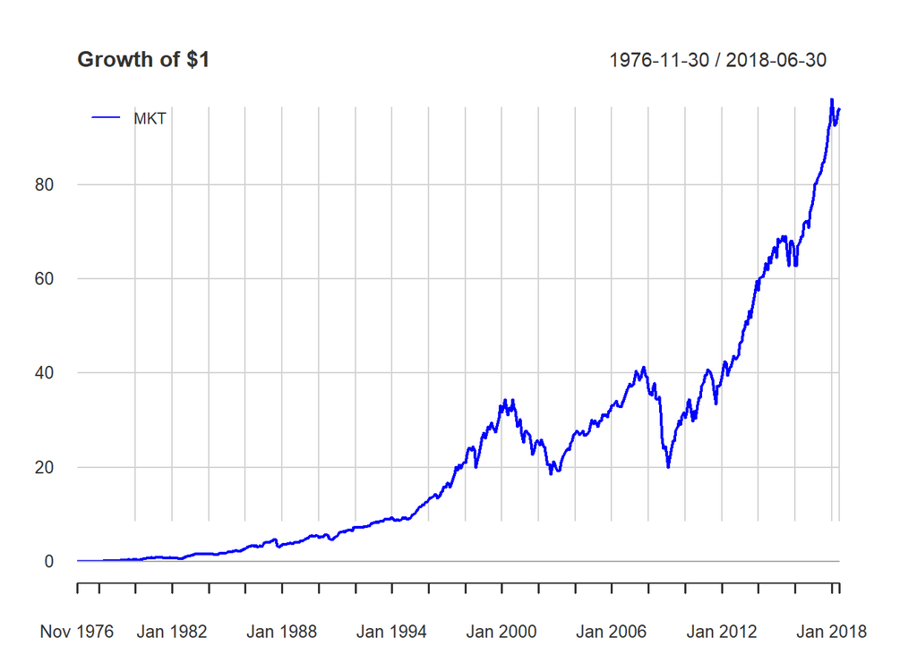

```r
plot2
```

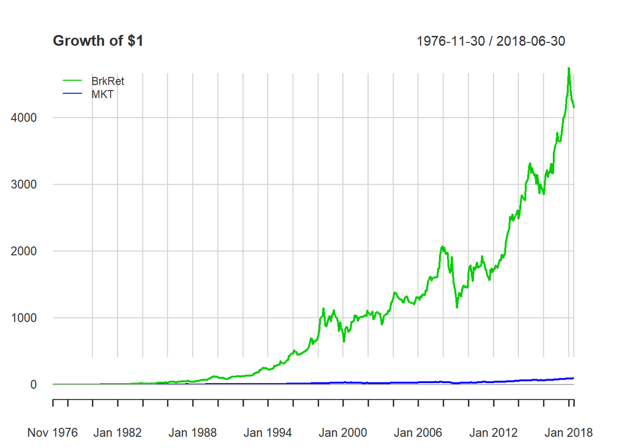

```r
plot3 <- chart.CumReturns(All.dat[,1:2],
                 wealth.index = FALSE,
                 Geometric = TRUE,
                 legend.loc = TRUE,
                 colorset = (3:4),
                 main="Growth of $1")
plot3
```

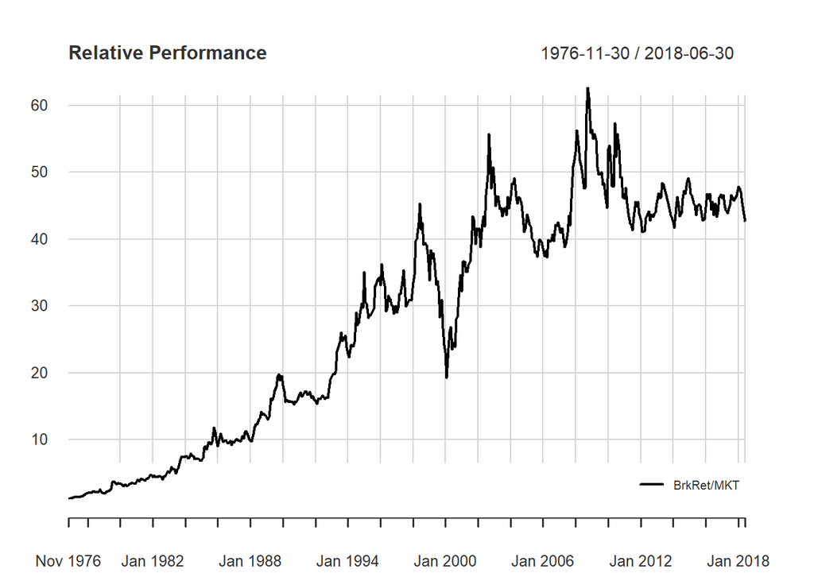

```r
chart.RelativePerformance(
  All.dat$BrkRet,
  All.dat$MKT,
  main = "Relative Performance",
  xaxis = TRUE,
  colorset = (1:12),
  legend.loc = "bottomright",
  ylog = TRUE,
  elementcolor = "darkgray",
  lty = 1,
  cex.legend = 0.7)
```

```r
Return.cumulative(All.dat$MKT,geometric=TRUE) # calculate cumulative return of aggregate market
```

```
##                        MKT
## Cumulative Return 96.22392
```

```r
table.Stats(All.dat$BrkRet)
```

```
##                   BrkRet
## Observations    500.0000
## NAs               0.0000
## Minimum          -0.2174
## Quartile 1       -0.0162
## Median            0.0122
## Arithmetic Mean   0.0190
## Geometric Mean    0.0168
## Quartile 3        0.0476
## Maximum           0.3548
## SE Mean           0.0030
## LCL Mean (0.95)   0.0131
## UCL Mean (0.95)   0.0249
## Variance          0.0046
## Stdev             0.0675
## Skewness          0.6987
## Kurtosis          2.8198
```

```r
table.Stats(All.dat$MKT)
```

```
##                      MKT
## Observations    500.0000
## NAs               0.0000
## Minimum          -0.2264
## Quartile 1       -0.0156
## Median            0.0136
## Arithmetic Mean   0.0102
## Geometric Mean    0.0092
## Quartile 3        0.0389
## Maximum           0.1289
## SE Mean           0.0019
## LCL Mean (0.95)   0.0063
## UCL Mean (0.95)   0.0140
## Variance          0.0019
## Stdev             0.0436
## Skewness         -0.7281
## Kurtosis          2.3473
```

```r
### Part F ###
SharpeRatio(All.dat$BrkRet,All.dat$RF) # use Sharpe Ratio function calling Berkshire Hathaway return vs risk free rate
```

```
##                                    BrkRet
## StdDev Sharpe (Rf=0.4%, p=95%): 0.2262115
## VaR Sharpe (Rf=0.4%, p=95%):    0.2060944
## ES Sharpe (Rf=0.4%, p=95%):     0.1728184
```

```r
### Part G ###
SharpeRatio(All.dat$MKT,All.dat$RF) # use Sharpe Ratio function calling market return vs risk free rate
```

```
##                                        MKT
## StdDev Sharpe (Rf=0.4%, p=95%): 0.14794528
## VaR Sharpe (Rf=0.4%, p=95%):    0.09486128
## ES Sharpe (Rf=0.4%, p=95%):     0.05677763
```

```r
### Part H & I ###
alphabeta <- lm(BrkRet_Ex~MKT_Ex,data=All.dat) #
summary(alphabeta)
```

```
##
## Call:
## lm(formula = BrkRet_Ex ~ MKT_Ex, data = All.dat)
##
## Residuals:
##      Min       1Q   Median       3Q      Max
## -0.17263 -0.03475 -0.00688  0.02608  0.33062
##
## Coefficients:
##             Estimate Std. Error t value Pr(>|t|)
## (Intercept) 0.010829   0.002724   3.976 8.05e-05 ***
## MKT_Ex      0.689755   0.061777  11.165  < 2e-16 ***
## ---
## Signif. codes:  0 '***' 0.001 '**' 0.01 '*' 0.05 '.' 0.1 ' ' 1
##
## Residual standard error: 0.06025 on 498 degrees of freedom
## Multiple R-squared:  0.2002, Adjusted R-squared:  0.1986
## F-statistic: 124.7 on 1 and 498 DF,  p-value: < 2.2e-16
```